# Week 7

Elizabeth Delmelle

2024-02-29

Let’s begin with a warm-up exercise from last week. This question involves the use of multiple linear regression on the Auto data set. (a) Produce a scatterplot matrix which includes all of the variables in the data set. (b) Compute the matrix of correlations between the variables using the function cor(). You will need to exclude the name variable, which is qualitative. cor() (c) Use the lm() function to perform a multiple linear regression with mpg as the response and all other variables except name as the predictors. Use the summary() function to print the results. Comment on the output. For instance: #i. Is there a relationship between the predictors and the response? #ii. Which predictors appear to have a statistically significant relationship to the response?

```r
?Auto
```

```
## starting httpd help server ... done
```

# Step 1

Let’s begin with a scatterplot. There are several options. Here is one that cool kids these days might use.

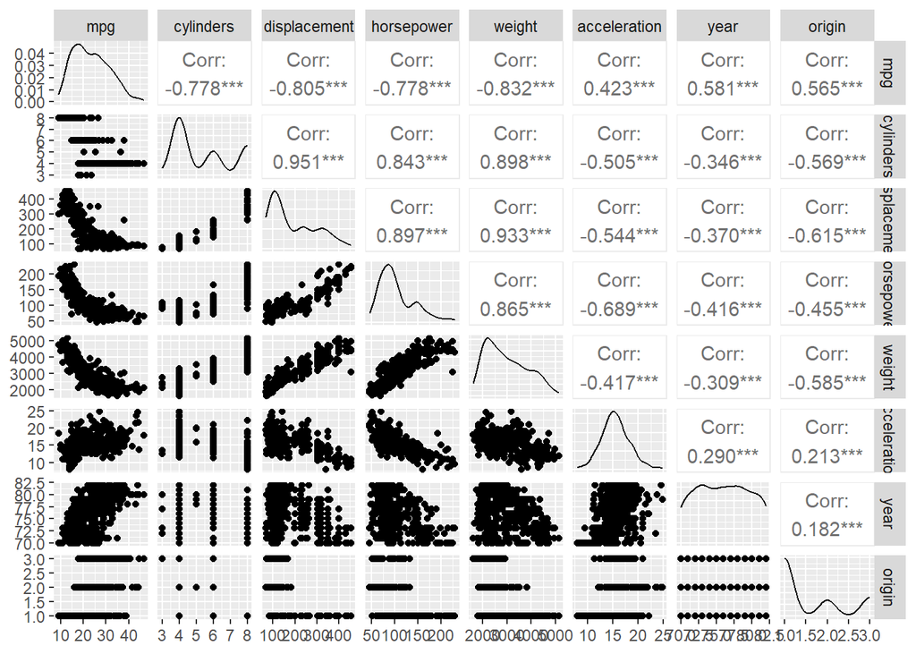

```r
# Produce scatterplot matrix
ggpairs(Auto[1:8])
```

This is a bit more old fashioned. Like myself.

```r
# Compute the matrix of correlations (excluding 'name' variable)
correlation_matrix <- cor(Auto[, -9])  # Excluding the 9th column (name)

# Print correlation matrix
print(correlation_matrix)
```

```
##                     mpg  cylinders displacement horsepower     weight
## mpg           1.0000000 -0.7776175   -0.8051269 -0.7784268 -0.8322442
## cylinders    -0.7776175  1.0000000    0.9508233  0.8429834  0.8975273
## displacement -0.8051269  0.9508233    1.0000000  0.8972570  0.9329944
## horsepower   -0.7784268  0.8429834    0.8972570  1.0000000  0.8645377
## weight       -0.8322442  0.8975273    0.9329944  0.8645377  1.0000000
## acceleration  0.4233285 -0.5046834   -0.5438005 -0.6891955 -0.4168392
## year          0.5805410 -0.3456474   -0.3698552 -0.4163615 -0.3091199
## origin        0.5652088 -0.5689316   -0.6145351 -0.4551715 -0.5850054
##              acceleration       year     origin
## mpg             0.4233285  0.5805410  0.5652088
## cylinders      -0.5046834 -0.3456474 -0.5689316
## displacement   -0.5438005 -0.3698552 -0.6145351
## horsepower     -0.6891955 -0.4163615 -0.4551715
## weight         -0.4168392 -0.3091199 -0.5850054
## acceleration    1.0000000  0.2903161  0.2127458
## year            0.2903161  1.0000000  0.1815277
## origin          0.2127458  0.1815277  1.0000000
```

Now run a regression. This is just a reminder of how to use all the variables and then update it in case you forget to exclude one. Like name

```r
lm.fit <- lm(mpg ~ ., data = Auto)
summary(lm.fit)
```

```
##
## Call:
## lm(formula = mpg ~ ., data = Auto)
##
## Residuals:
##    Min     1Q Median     3Q    Max
## -5.646  0.000  0.000  0.000  5.646
##
## Coefficients: (1 not defined because of singularities)
##                                            Estimate Std. Error t value Pr(>|t|)
## (Intercept)                                0.187305  12.773943   0.015 0.988335
## cylinders                                 -0.918096   0.616653  -1.489 0.140231
## displacement                               0.003041   0.015621   0.195 0.846109
## horsepower                                -0.042342   0.029070  -1.457 0.148919
## weight                                    -0.004193   0.001209  -3.467 0.000829
## acceleration                              -0.481449   0.171537  -2.807 0.006206
## year                                       0.636498   0.112195   5.673 1.89e-07
## origin                                     1.324264   4.243221   0.312 0.755737
## nameamc ambassador dpl                     3.371358   3.245610   1.039 0.301870
## nameamc ambassador sst                     3.364264   3.270924   1.029 0.306616
## nameamc concord                           -0.122500   3.275058  -0.037 0.970251
## nameamc concord d/l                       -1.686548   3.422955  -0.493 0.623483
## nameamc concord dl 6                      -0.529687   3.514452  -0.151 0.880556
## nameamc gremlin                           -0.426606   2.958293  -0.144 0.885679
## nameamc hornet                             0.269026   2.902972   0.093 0.926382
## nameamc hornet sportabout (sw)            -0.403111   3.527112  -0.114 0.909278
## nameamc matador                            0.462233   2.667735   0.173 0.862853
## nameamc matador (sw)                       3.118929   2.894160   1.078 0.284233
## nameamc pacer                              0.012163   3.519402   0.003 0.997251
## nameamc pacer d/l                         -1.682001   3.517154  -0.478 0.633716
## nameamc rebel sst                          2.875941   3.284138   0.876 0.383658
## nameamc spirit dl                          0.713000   4.063462   0.175 0.861131
## nameaudi 100 ls                            0.936254   3.449074   0.271 0.786702
## nameaudi 100ls                            -3.133448   2.984726  -1.050 0.296773
## nameaudi 4000                              4.004843   3.244193   1.234 0.220431
## nameaudi 5000                             -4.109082   3.450859  -1.191 0.237070
## nameaudi 5000s (diesel)                   11.652927   3.494256   3.335 0.001266
## nameaudi fox                               3.199486   3.328970   0.961 0.339226
## namebmw 2002                               2.082893   3.429803   0.607 0.545276
## namebmw 320i                              -5.320674   3.378167  -1.575 0.118967
```

[output cut: 578 more lines]

```
## namevolvo 244dl
## namevolvo 245
## namevolvo 264gl
## namevolvo diesel                         *
## namevw dasher (diesel)                   ***
## namevw pickup                            ***
## namevw rabbit                            .
## namevw rabbit c (diesel)                 ***
## namevw rabbit custom
## ---
## Signif. codes:  0 '***' 0.001 '**' 0.01 '*' 0.05 '.' 0.1 ' ' 1
##
## Residual standard error: 2.272 on 85 degrees of freedom
## Multiple R-squared:  0.9816, Adjusted R-squared:  0.9153
## F-statistic:  14.8 on 306 and 85 DF,  p-value: < 2.2e-16
```

```r
lm.fit1 <- update(lm.fit , ~ . - name)
summary(lm.fit1)
```

```
##
## Call:
## lm(formula = mpg ~ cylinders + displacement + horsepower + weight +
##     acceleration + year + origin, data = Auto)
##
## Residuals:
##     Min      1Q  Median      3Q     Max
## -9.5903 -2.1565 -0.1169  1.8690 13.0604
##
## Coefficients:
##                Estimate Std. Error t value Pr(>|t|)
## (Intercept)  -17.218435   4.644294  -3.707  0.00024 ***
## cylinders     -0.493376   0.323282  -1.526  0.12780
## displacement   0.019896   0.007515   2.647  0.00844 **
## horsepower    -0.016951   0.013787  -1.230  0.21963
## weight        -0.006474   0.000652  -9.929  < 2e-16 ***
## acceleration   0.080576   0.098845   0.815  0.41548
## year           0.750773   0.050973  14.729  < 2e-16 ***
## origin         1.426141   0.278136   5.127 4.67e-07 ***
## ---
## Signif. codes:  0 '***' 0.001 '**' 0.01 '*' 0.05 '.' 0.1 ' ' 1
##
## Residual standard error: 3.328 on 384 degrees of freedom
## Multiple R-squared:  0.8215, Adjusted R-squared:  0.8182
## F-statistic: 252.4 on 7 and 384 DF,  p-value: < 2.2e-16
```

Note: Notice that the coefficient for displacement is very different from the correlation test observation. The issue has probably arisen due to multicolinearity.